# rapport_td8_simon_jiaxuan

# Exercice 1:

## Question 1:

Pour derminer la loi de la variable $X_n$, d’après l’équation de l’énoncé, on peut savoir que $X_n$ a deux états: 0 et 1, donc $X_n$ est une variable Bernoulli, et $X_n \sim Binomiale(p)$, pour calculer la paramètre p:

$P(X_n=1)=P(U_n^2+V_n^2 \leq1)=\int_{}^{}P(U_n^2+V_n^2 \leq1\mid U_n=u)\times f_U(u) du$

$=\int_{0}^{1}P(u^2+V_n^2 \leq1) du$ parce que u est compris entre 0 et 1

$=\int_{0}^{1}P(V_n \leq \sqrt{1-u^2}) du$

$=\int_{0}^{1} \sqrt{1-u^2} du$ car $V_n$ est dans l’intervalle [0,1], donc $P(V_n \leq \sqrt{1-u^2})=\sqrt{1-u^2}$

Ici on effectue un changement de variable, en raison de $U_n^2+V_n^2 \leq1$, donc on peut poser $U_n^2 = sin^2x$ et $V_n^2 = cos^2x$, puis on a $u^2 = sin^2x$, avec $u = sinx$, on peut déduire que $du = cosx\times dx$

$=\int_{0}^{\frac{\pi}{2}} \sqrt{1-sin^2x}\times cosx dx$

$=\int_{0}^{\frac{\pi}{2}} cos^2x dx$

or $cos^2x = \frac{cos2x +1}{2}$

$=\int_{0}^{\frac{\pi}{2}} \frac{cos2x +1}{2} dx$

$=\frac{\pi}{4}$

comme ça, $p=\frac{\pi}{4}$, donc $X_n \sim Binomiale(\frac{\pi}{4})$

Pour calculer la variance de $Z_n$ et montrer que $Z_n$ converge vers $\pi$

$Var[Z_n]=\frac{4^2}{n^2} \times Var[\sum^n_{i=1}X_i]$ ici en appliquant la propiété de variance

donc par indépendant des $X_i$,

$Var[Z_n]=\frac{4^2}{n^2}\times \sum^n_{i=1}Var[X_i]$

et comme $X_i$ suit une loi de Bernoulli, et son paramètre: $p=\frac{\pi}{4}$

$Var[Z_n]=\frac{4^2}{n^2}\times \sum^n_{i=1}\frac{\pi}{4}\times (1-\frac{\pi}{4})$

$=\frac{1}{n}\pi(4-\pi)$

donc $\lim_{n \rightarrow +\propto} \frac{1}{n}\pi(4-\pi)=0$

pour montrer que la suite $Z_n$ converge vers $\pi$

$E[Z]=E[\frac{4}{n}\sum^n_{i=1}X_i]=\frac{4}{n}\times n \times \frac{\pi}{4}=\pi$

(La question suivante nous permettra de finir la demonstration en même temps grâce à l’inégalité de Chebishev)

## Qestion 2:

D’après le théorème de Chebishev, on a :

$\forall\epsilon>0, P(|z-\pi|>\epsilon)\leq\alpha=0(\frac{1}{n})$

et on veut que $P(|Z_n-\pi|\leq\epsilon)\geq95$%$=1-\alpha$

$=> 1-P(|Z_n-\pi|>\epsilon)\geq1-\alpha$

donc $P(|Z_n-\pi|>\epsilon)\leq\alpha$

or $Var[Z_n]=\frac{\pi(4-\pi)}{n}$

finalement on va chercher le $n_0$ qui est inférieure ou équale $n$

$\frac{\pi(4-\pi)}{n\epsilon^2}\leq\alpha$

donc $n_0=\lceil\frac{\pi(4-\pi)}{\alpha\epsilon^2}\rceil$

```r
epsilon <- 1e-3
alpha <- 0.05
n <- ceiling( pi*(4-pi)/(alpha*epsilon^2))
log10(n)
```

```
## [1] 7.731873
```

```r
u <- runif(n)
v <- runif(n)
4*mean(u^2 + v^2 < 1) - pi
```

```
## [1] 2.17151e-05
```

## Question 3:

$\frac{1}{\sqrt{n}}\sum X_n-\sqrt{n} \times \mu$

$=\sqrt{n}(Z_n-\pi)$

$Var[\sqrt{n}(Z_n-\pi)]=n\cdot Var[Z_n-\pi]$ par la propiété de la variance

$=n\cdot Var[Z_n]$

$=\pi\cdot(4-\pi)$ donc cette variance est une constante

La loi connue qui semble correspondre à $Z_n$ est la loi normale.

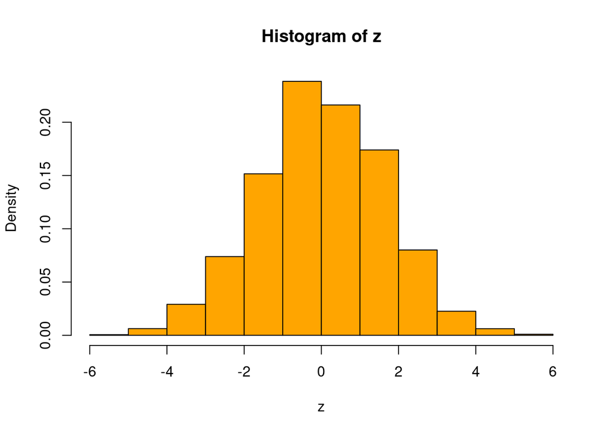

```r
rzn <- function(m=1,n=1000){
  zn <- NULL
  for (i in 1:m){
    u <- runif(n)
    v <- runif(n)
    zn <- c(zn, 4*mean(u^2 + v^2 < 1) )
  }
  return(zn)
}
n <- 3000
m <- 10000
z  <- sqrt(n)*(rzn(m,n) - pi)
hist(z, prob = TRUE, col = "orange")
```

### Exercice 2:

## Qestion 1:

$E[y_n]=E[\varphi (U_i)]$

$or$ $u\sim U(0,1)$

$=\int_0^1 \varphi(u) du$

$=\mathcal{I}$

(L’utilisation du théorème de Chebichev avec la variance déterminée dans la question suivante permet alors de conclure)

## Question 2:

$Var[y_n]=\frac{1}{n}\cdot Var[\varphi(u)]$

$=\frac{1}{n}(E[\varphi(u)^2]-E[\varphi(u)]^2)$

$=\frac{1}{n}\cdot(\int_0^1\varphi(u)^2du - I)$

$=\frac{1}{n}\cdot(\int_0^1u^3du -\int_0^1u^4du -\frac{\pi^2}{256})$

$=\frac{1}{n}\cdot(\frac{1}{4}-\frac{1}{5}-\frac{\pi^2}{256})$

apres le théorème de chebichev:

$\approx\frac{0.0114}{\epsilon^2 n}$

et $\epsilon = 10^{-3}, \alpha=0.05$

donc:

$n\geq\frac{Var[\varphi(u)]}{\alpha\epsilon^2}>228 937$

## Question 3:

Par linéarité de l’espérance et identique distribution de $V_i$

$E[Z_n]=E[\frac{\varphi(v)}{f(v)}]$

or par le théorème de transfert, $E[g(v)]=\int_0^1g(v)f(v)dv$

donc

$E[Z_n]=\int_0^1\frac{\varphi(v)}{f(v)}f(v)dv=I$

et on veut que $Var[Z_n]\rightarrow0$ quand $n\rightarrow\infty$

or $Var[Z_n]=\frac{1}{n}(E[\frac{\varphi(v)^2}{f(v)^2}]-E[\frac{\varphi(v)}{f(v)}]^2)$

$=\frac{1}{n}(\int_0^1\frac{\varphi(v)^2}{f(v)}dv-I^2)$

$=\frac{1}{n}(\int_0^1\frac{v^2(1-v)}{6v(1-v)}dv-\frac{\pi^2}{256})$

$=\frac{1}{n}(\frac{1}{18}-\frac{\pi^2}{256})$

## Question 4:

```r
phi <- function(u){ sqrt((1-u)*u^3)}
n <- 1000000
# Algorithme 1

mean(y <- phi(runif(n))) - pi/16
```

```
## [1] -0.0003322266
```

```r
var(y)
```

```
## [1] 0.01145792
```

```r
# Algorithme 2
f <- function(v){dbeta(v,2,2)}
u <- rbeta(n, 2, 2)
mean(z <- phi(u)/f(u)) - pi/16
```

```
## [1] 0.0002719866
```

```r
var(z)
```

```
## [1] 0.01714677
```

En conclusion, entre les deux algorithmes, on prefère à choisir le premier car il est plus simple.

## Question 5:

on choisit le $C_\alpha$ tel que:

$\int_0^1f_\alpha(v)dv=1$

ie $C_\alpha=(\int_0^1v^\alpha(1-v)dv)^{-1}$

$=(\frac{1}{\alpha+1}-\frac{1}{\alpha+2})^{-1}$

$=(\alpha+1)\cdot(\alpha+2)$

donc on cherche à minimiser (selon le $\alpha$)

$E[\frac{\varphi(v)^2}{f_\alpha(v)^2}]- I^2$

autrement dit:

$\int_0^1\frac{\varphi(v)^2}{f_\alpha(v)}dv -I^2$

$=\frac{1}{(4-\alpha)(\alpha+1)(\alpha+2)}-I^2$

docn $\frac{d[(4-\alpha)(\alpha+1)(\alpha+2)]}{d\alpha}=-\frac{(4-\alpha)(\alpha+1)+(4-\alpha)(\alpha+2)-(\alpha+1)(\alpha+2)}{((4-\alpha)(\alpha+1)(\alpha+2))^{2}}$

or $P(\alpha)=-3\alpha^2+(3+2-3)\alpha+4+8-2$

$=-3(\alpha-\frac{1}{3}-\frac{\sqrt{31}}{3})(\alpha-\frac{1}{3}+\frac{\sqrt{31}}{3})$

donc minimal pour $\alpha=\frac{1+\sqrt{31}}{3}\approx2,19$